# PROP_ADAIR - Phytophthora Analysis

2022-05-11

Samples were analyzed for Phytophthora by the Agdia Phytophtora ELISA kit. Samples were collected from both rows, but unfortunately citrus roots were difficult to obtain from trees in row 17W as most of the root mass surrounding the trees were from the Eucalyptus trees.

Since there were very few samples from the 17W, I subset the data and only analyzed the samples from 17E to obtain a balanced experimental design. Each sample was run in duplicate on the microplate and the resulting values were averaged across the 2 tree plots.

The table below shows the average value for each rs:prop combination. The cutoff value for positive samples is approx 0.37.

Mean Values of Raw Readings by Combination

| rs | prop | avg_reading | SD |
| --- | --- | --- | --- |
| US-1516 | ct | 2.1255000 | 0.2671448 |
| US-1516 | mpg | 0.5572167 | 0.4085834 |
| US-1516 | sd | 0.3084000 | 0.0965572 |
| US-812 | ct | 1.2872667 | 1.5445715 |
| US-812 | mpg | 1.0325500 | 0.8894089 |
| US-812 | sd | 1.0225917 | 0.7634375 |
| US-897 | ct | 0.9576750 | 0.9336465 |
| US-897 | mpg | 2.0528000 | 1.4684115 |
| US-897 | sd | 1.5456667 | 0.6896021 |
| US-942 | ct | 1.8063083 | 0.5188132 |
| US-942 | mpg | 0.9261333 | 0.8379327 |
| US-942 | sd | 0.7891083 | 0.8685868 |

Percentage of Positive Samples by Combination

| rs | prop | Percent Pos |
| --- | --- | --- |
| US-1516 | ct | 66.67 |
| US-1516 | mpg | 50.00 |
| US-1516 | sd | 33.33 |
| US-812 | ct | 66.67 |
| US-812 | mpg | 83.33 |
| US-812 | sd | 66.67 |
| US-897 | ct | 50.00 |
| US-897 | mpg | 100.00 |
| US-897 | sd | 66.67 |
| US-942 | ct | 100.00 |
| US-942 | mpg | 50.00 |
| US-942 | sd | 16.67 |

### Raw Data ANOVA Results

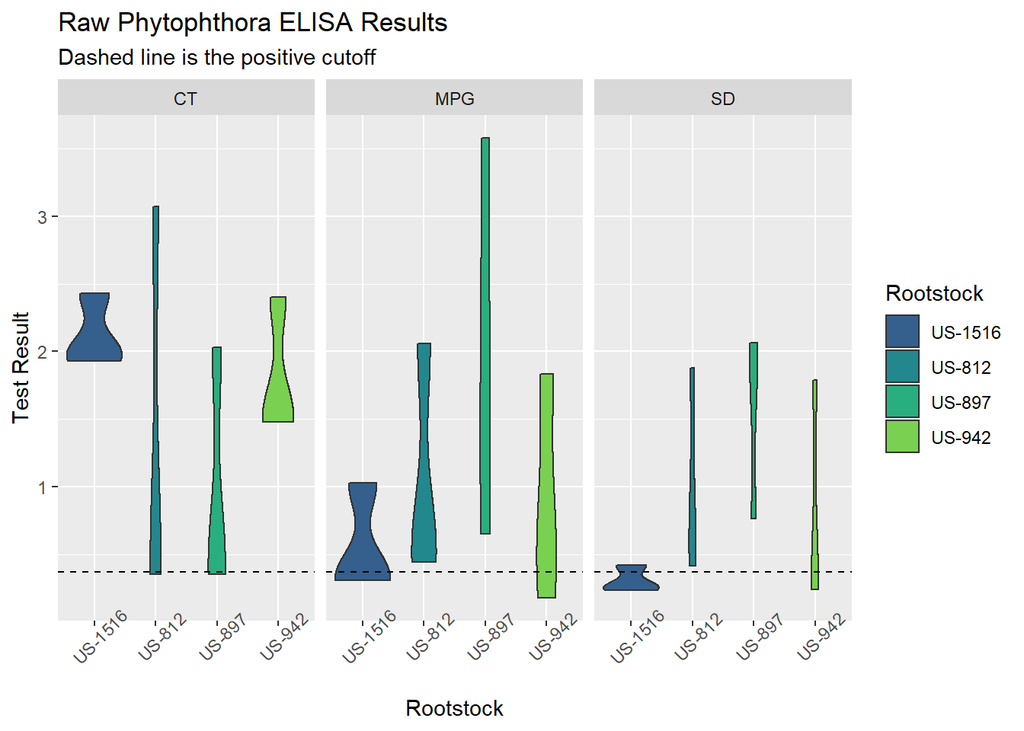

```r
lm1 <- lm(value ~ rs*prop, data1)

summary(lm1)
```

```
##
## Call:
## lm(formula = value ~ rs * prop, data = data1)
##
## Residuals:
##     Min      1Q  Median      3Q     Max
## -1.4025 -0.4881 -0.1765  0.4836  1.7827
##
## Coefficients:
##                  Estimate Std. Error t value Pr(>|t|)
## (Intercept)        2.1255     0.5065   4.196 0.000321 ***
## rsUS-812          -0.8382     0.7163  -1.170 0.253422
## rsUS-897          -1.1678     0.7163  -1.630 0.116098
## rsUS-942          -0.3192     0.7163  -0.446 0.659887
## propmpg           -1.5683     0.7163  -2.189 0.038534 *
## propsd            -1.8171     0.7163  -2.537 0.018110 *
## rsUS-812:propmpg   1.3136     1.0131   1.297 0.207082
## rsUS-897:propmpg   2.6634     1.0131   2.629 0.014703 *
## rsUS-942:propmpg   0.6881     1.0131   0.679 0.503482
## rsUS-812:propsd    1.5524     1.0131   1.532 0.138494
## rsUS-897:propsd    2.4051     1.0131   2.374 0.025936 *
## rsUS-942:propsd    0.7999     1.0131   0.790 0.437496
## ---
## Signif. codes:  0 '***' 0.001 '**' 0.01 '*' 0.05 '.' 0.1 ' ' 1
##
## Residual standard error: 0.8773 on 24 degrees of freedom
## Multiple R-squared:  0.3721, Adjusted R-squared:  0.08428
## F-statistic: 1.293 on 11 and 24 DF,  p-value: 0.2868
```

Block factors were removed as they were insignificant at p>0.70.

Raw Data Linear Model ANOVA Results

|  | Df | Sum Sq | Mean Sq | F value | Pr(>F) |
| --- | --- | --- | --- | --- | --- |
| rs | 3 | 1.357422 | 0.4524741 | 0.5878553 | 0.6288671 |
| prop | 2 | 2.426538 | 1.2132688 | 1.5762816 | 0.2274076 |
| rs:prop | 6 | 7.162167 | 1.1936944 | 1.5508505 | 0.2047189 |
| Residuals | 24 | 18.472874 | 0.7697031 |  |  |

### Log Transformed Data ANOVA Results

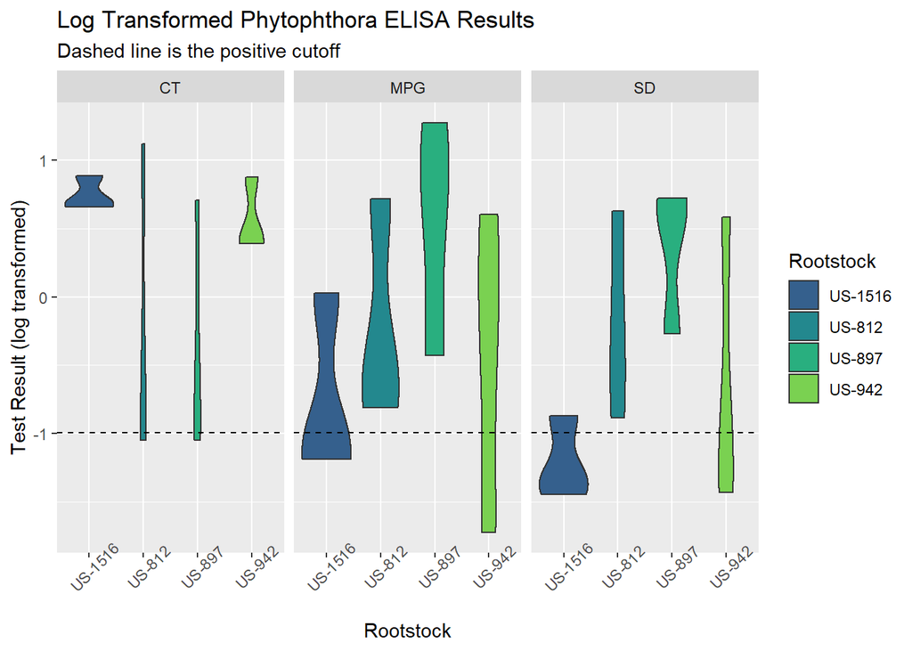

```r
lm2 <- lm(log(value) ~ rs*prop, data1)

summary(lm2)
```

```
##
## Call:
## lm(formula = log(value) ~ rs * prop, data = data1)
##
## Residuals:
##      Min       1Q   Median       3Q      Max
## -1.26334 -0.47291 -0.09432  0.34516  1.37001
##
## Coefficients:
##                  Estimate Std. Error t value Pr(>|t|)
## (Intercept)        0.7489     0.4639   1.614  0.11951
## rsUS-812          -0.9973     0.6561  -1.520  0.14156
## rsUS-897          -1.0999     0.6561  -1.677  0.10660
## rsUS-942          -0.1831     0.6561  -0.279  0.78258
## propmpg           -1.4969     0.6561  -2.282  0.03167 *
## propsd            -1.9560     0.6561  -2.981  0.00649 **
## rsUS-812:propmpg   1.5434     0.9278   1.663  0.10923
## rsUS-897:propmpg   2.3485     0.9278   2.531  0.01833 *
## rsUS-942:propmpg   0.4702     0.9278   0.507  0.61691
## rsUS-812:propsd    2.0349     0.9278   2.193  0.03821 *
## rsUS-897:propsd    2.6562     0.9278   2.863  0.00857 **
## rsUS-942:propsd    0.7456     0.9278   0.804  0.42952
## ---
## Signif. codes:  0 '***' 0.001 '**' 0.01 '*' 0.05 '.' 0.1 ' ' 1
##
## Residual standard error: 0.8035 on 24 degrees of freedom
## Multiple R-squared:  0.4278, Adjusted R-squared:  0.1656
## F-statistic: 1.631 on 11 and 24 DF,  p-value: 0.1527
```

```r
anova(lm2)
```

```
## Analysis of Variance Table
##
## Response: log(value)
##           Df  Sum Sq Mean Sq F value Pr(>F)
## rs         3  1.5075 0.50250  0.7783 0.5176
## prop       2  2.2303 1.11515  1.7273 0.1991
## rs:prop    6  7.8478 1.30796  2.0259 0.1014
## Residuals 24 15.4946 0.64561
```

Block effects were removed as they were insignificant at p > 0.89

Log Transformed Linear Model ANOVA

|  | Df | Sum Sq | Mean Sq | F value | Pr(>F) |
| --- | --- | --- | --- | --- | --- |
| rs | 3 | 1.507512 | 0.5025039 | 0.7783397 | 0.5176026 |
| prop | 2 | 2.230296 | 1.1151478 | 1.7272778 | 0.1991415 |
| rs:prop | 6 | 7.847755 | 1.3079592 | 2.0259278 | 0.1013702 |
| Residuals | 24 | 15.494640 | 0.6456100 |  |  |

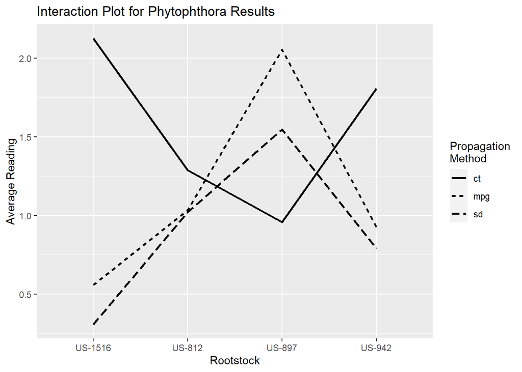

```r
ggplot(averages, aes(x = rs, y = avg_reading, linetype = prop, group = prop))+
        geom_line(size = 1)+
        labs(title = "Interaction Plot for Phytophthora Results",
             x = 'Rootstock',
             y = 'Average Reading',
             linetype = 'Propagation\nMethod')
```

### Logistic Regression Model

I also tried a logistic regresssion model to test whether or not the binary response variable (positive or negative) could be linked to any rootstock or not. However, after looking at the coefficients below, none are close to being significant. It would seem that the positive samples are distributed in a fairly random fashion both across the field and rootstock/propagation method combinations.

```r
log1 <- glm(pos ~ rs*prop, data = data2, family = 'binomial')
summary(log1)
```

```
##
## Call:
## glm(formula = pos ~ rs * prop, family = "binomial", data = data2)
##
## Deviance Residuals:
##      Min        1Q    Median        3Q       Max
## -1.89302  -0.96974   0.00013   0.90052   1.89302
##
## Coefficients:
##                    Estimate Std. Error z value Pr(>|z|)
## (Intercept)       6.931e-01  8.660e-01   0.800    0.423
## rsUS-812          6.193e-15  1.225e+00   0.000    1.000
## rsUS-897         -6.931e-01  1.190e+00  -0.582    0.560
## rsUS-942          1.787e+01  2.663e+03   0.007    0.995
## propmpg          -6.931e-01  1.190e+00  -0.582    0.560
## propsd           -1.386e+00  1.225e+00  -1.132    0.258
## rsUS-812:propmpg  1.609e+00  1.835e+00   0.877    0.380
## rsUS-897:propmpg  1.926e+01  2.663e+03   0.007    0.994
## rsUS-942:propmpg -1.787e+01  2.663e+03  -0.007    0.995
## rsUS-812:propsd   1.386e+00  1.732e+00   0.800    0.423
## rsUS-897:propsd   2.079e+00  1.708e+00   1.218    0.223
## rsUS-942:propsd  -1.879e+01  2.663e+03  -0.007    0.994
##
## (Dispersion parameter for binomial family taken to be 1)
##
##     Null deviance: 95.265  on 71  degrees of freedom
## Residual deviance: 73.958  on 60  degrees of freedom
## AIC: 97.958
##
## Number of Fisher Scoring iterations: 17
```